# Redukcja zmiennych i klasteryzacja

Małgorzata Wachulec, Mateusz Bąkała, Wojciech Bogucki

03 - 06 - 2019

# Redukcja zmiennych

### Oryginalne dane

Oryginalne dane zaczerpnięte ze źródła podzielone były na zbiory treningowy i testowy. Ponadto jedna kolumna kategoryczna przechowywana była w oddzielnym pliku. Jako że naszym celem była klasteryzacja, połączyliśmy ze sobą treningowy i testowy zbiór, otrzymując 10299 obserwacji o 561 cechach. Po dodanie kategorycznej kolumny opisującej numer obserwowanego ochotnika zgłoszonego do eksperymentu i wykonaniu *one-hot encodingu* liczba kolumn wzrosła do 591.

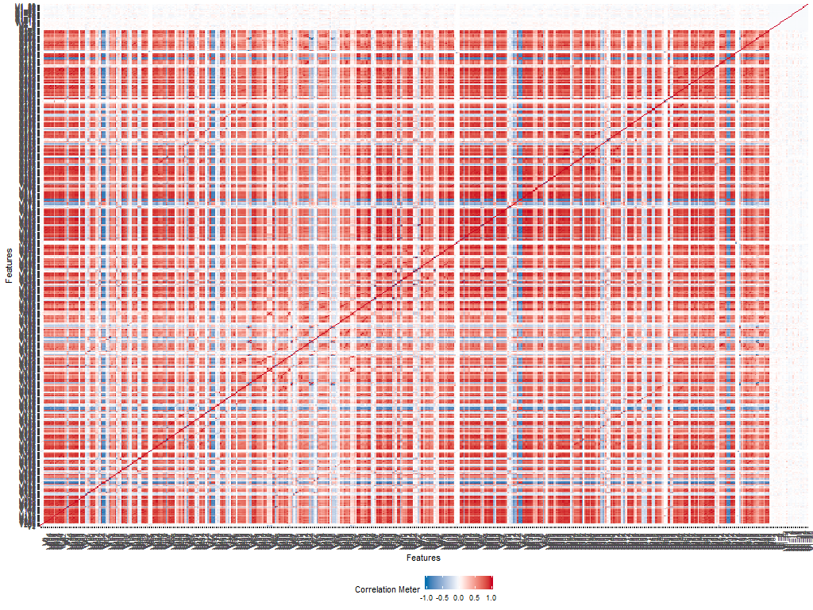

Macierz korelacji dla oryginalnych danych

### Dane po correlation clustering

Uznaliśmy, że 591 kolumn to może być zbyt duża liczba jak na możliwości naszych komputerów, a i wiele kolumn było ze sobą mocno skorelowanych. Rozwiązaniem naszych problemów miało być *correlation clustering* (według amatorskiego tłumaczenia: klastrowanie korelacyjne).

Aby umożliwić budowanie klastrów na korelacji, musieliśmy najpierw wyprodukować macierz odległości kolumn, którą mogliśmy się posłużyć potem w modelu hierarchicznym. Naszym pomysłem było policzenie korelacji, a potem przekształcenie ich poprzez nałożenie na ich wartość bezwzględną logarytmu (jako że wartości korelacji mieszczą się w przedziale [-1; 1]) i przemnożenie przez -1, by wartości były dodatnie. Dzięki temu kolumny idealnie skorelowane miały odległość równą 0, a nieskorelowane - bardzo dużą.

Następnie zaczęliśmy szukać tej jedynej, idealnej liczby klastrów kolumnowych. W tym celu wygenerowaliśmy drzewo algorytmem `hclust2` z biblioteki `genie`, a następnie cięliśmy je na wszystkie strony. Wygenerowane gałązki mierzyliśmy indeksami wewnętrznymi - mianowicie - indeksem Dunna i indeksem C - aby zobaczyć, przy której wartości tracimy więcej na dodanej złożoności niż zyskujemy na zachowanej informacji.

Po dłuższym czasie spędzonym na testowaniu różnych wartości, głaskaniu jeża i oglądaniu podobnych do siebie wykresów doszliśmy do punktu, w którym byliśmy w stanie zlokalizować optimum gdzieś w przedziale 60-70 kolumn. Policzywszy lokalne maksimum, uzyskaliśmy optymalną wartość 66 kolumn.

Mogliśmy wówczas wybrać najbardziej reprezentatywne kolumny. Dysponowaliśmy 66 klastrami, czasami jednostkowymi w wielkości, czasami większymi. Z każdego klastra wybraliśmy jedną kolumnę - tę, która wykazywała największą średnią korelację z pozostałymi kolumnami w klastrze (oczywiście problem, w której w klastrze była tylko jedna kolumna, był trywialny niczym kolorowanie grafu o jednym wierzchołku). Uzyskane indeksy kolumn zapisaliśmy w oddzielnym pliku w celu ułatwienia dostępu do policzonych wyników.

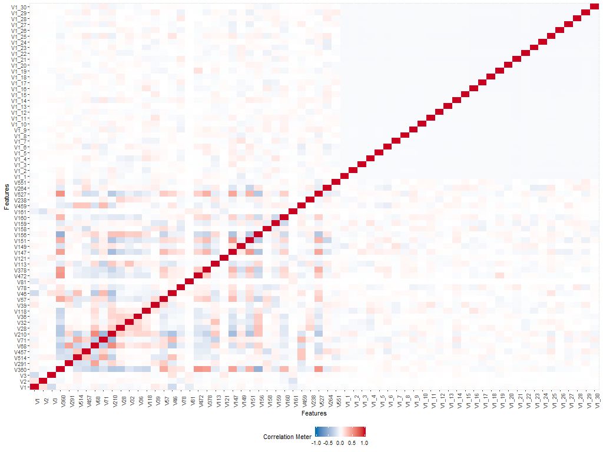

Macierz korelacji dla wybranych kolumn

### Dane z PCA

Jako inny sposób redukcji wymiarów sprawdziliśmy analizę głównych składowych(PCA). Użyliśmy do tego funkcji `dudi.pca()` z pakietu `ade4`.

```r
pca_ade <- ade4::dudi.pca(data$X, nf=50, scannf = FALSE)

data_ade <- pca_ade$l1
```

W obiekcie `pca_ade` znajdowała się znormalizowana macierz współrzędnych każdej obserwacji względem 50 najważniejszych składowych(`l1`). Wybraliśmy tę ramkę danych ze względu na bardzo dobry wynik dla klasteryzacji metodą k-średnich.

# Klasteryzacja

### Metody klasteryzowania

Dla każdego z trzech zbiorów danych zastosowaliśmy następujące algorytmy klasteryzujące z biblioteki mlr:

- cluster.SimpleKMeans
- cluster.XMeans
- cluster.FarthestFirst
- cluster.kmeans
- cluster.Cobweb
- cluster.cmeans

oraz algorytmy z innych bibliotek, np.

- genie::hclust2
- mclust::mclust
- cluster::pam

Następnie, dla każdej z powyższych klasteryzacji obliczyliśmy indeksy zewnętrzne (wykorzystujące etykiety):

- Rand
- Jaccard
- Fowkles.Mallows
- Russel.Rao

oraz indeksy wewnętrzne (badające strukturę klastrów):

- Davies.Bouldin
- Dunn
- Xie.Beni

a także zapisaliśmy czas potrzebny dla danej klasteryzacji. W ten sposób zebraliśmy materiał do porównania różnych metod klasteryzacji dla każdego zbioru danych. Indeksy Davies.Bouldin oraz Xie.Beni staraliśmy się minimalizować, a pozostałe maksymalizujemy. Przykładowa tabela, w której zbieraliśmy dane dla zredukowanego zbioru danych, wygląda następująco:

Dane zebrane dla zredukowanej ramki danych przy użyciu ade4

| External.Rand | External.Jaccard | External.Fowlkes.Mallows | External.Russel.Rao | Internal.Davies.Bouldin | Internal.Dunn | Internal.Xie.Beni | time | name |
| --- | --- | --- | --- | --- | --- | --- | --- | --- |
| 0.850 | 0.447 | 0.624 | 0.121 | 4.597 | 0.055 | 6.089 | 0.099 | cluster.kmeans |
| 0.800 | 0.327 | 0.498 | 0.097 | 2.615 | 0.078 | 4.118 | 314.860 | mclust::Mclust |
| 0.793 | 0.444 | 0.662 | 0.165 | 5.685 | 0.050 | 6.948 | 18.813 | cluster.XMeans |
| 0.732 | 0.126 | 0.223 | 0.038 | 10.081 | 0.049 | 24.890 | 13.210 | cluster::pam |
| 0.729 | 0.109 | 0.196 | 0.033 | 33.936 | 0.023 | 35.550 | 0.100 | cluster.cmeans |
| 0.664 | 0.334 | 0.578 | 0.168 | 6.773 | 0.087 | 2.372 | 0.591 | cluster.SimpleKMeans |
| 0.620 | 0.231 | 0.419 | 0.114 | 5.794 | 0.091 | 2.328 | 2.302 | genie::hclust2 |

Wyliczyliśmy średnią wartość każdego z indeksów zewnętrznych, korzystających z prawdziwych etykiet, dla każdego zbioru danych (po różnych metodach klasteryzacji) i porównaliśmy je na poniższym wykresie:

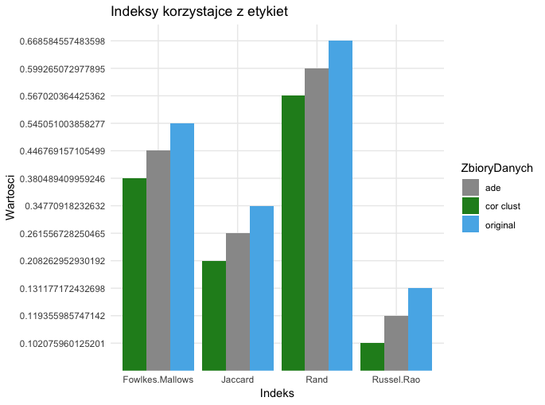

Widzimy, że średnio metody klasteryzujące dają najlepsze wyniki na pełnym zbiorze danych. Drugie najwyższe wartości indeksów są otrzymywane na zbiorze otrzymanym przez ade, natomiast zbiór danych otrzymany dzięki correlation clustering ma najniższe wartości indeksów dla różnych metod klasteryzacji.

Skoro wiemy już, które zbiory danych okazały się być najowocniejsze, sprawdźmy, które z metod klasteryzacji radzą sobie na nich najlepiej.

# Najlepszy model

Przywołajmy analogiczną ramkę, tym razem jednak dla zewnętrznych indeksów oraz oryginalnych danych (jako że okazały się dawać najlepsze rezultaty).

Dane zebrane dla oryginalnej ramki danych

| External.Rand | External.Jaccard | External.Fowlkes.Mallows | External.Russel.Rao | time | name |
| --- | --- | --- | --- | --- | --- |
| 0.842 | 0.470 | 0.657 | 0.140 | 8.689 | cluster.XMeans |
| 0.857 | 0.463 | 0.639 | 0.123 | 19.206 | genie::hclust2 |
| 0.664 | 0.333 | 0.577 | 0.168 | 5.332 | cluster.SimpleKMeans |
| 0.849 | 0.392 | 0.564 | 0.097 | 202.500 | cluster::pam |
| 0.843 | 0.385 | 0.557 | 0.098 | 1.227 | cluster.kmeans |
| 0.764 | 0.285 | 0.453 | 0.094 | 4.238 | cluster.cmeans |
| 0.169 | 0.169 | 0.411 | 0.169 | 229.588 | cluster.Cobweb |
| 0.172 | 0.169 | 0.410 | 0.168 | 4.350 | cluster.FarthestFirst |

Algorytmy `cluster.FarthestFirst` i `cluster.Cobweb`, pomimo naszych usilnych prób i najszczerszych chęci, zdawały się konsekwentnie twierdzić, że lepiej od nas znają wewnętrzną strukturę danych, i zwracały klastrowania z jednym bądź dwoma klastrami. Stąd ich, potocznie mówiąc, “patologiczne” wyniki i nasza propozycja, by najlepszego modelu szukać gdzie indziej.

Słaba wartość indeksu Randa wyklucza `cluster.SimpleKMeans` i (w mniejszym stopniu) `cluster.cmeans`. Indeks Jaccarda zawęża nasze poszukiwania do dwóch kandydatów: `cluster.XMeans` oraz `genie::hclust2`. Analiza Fowlkesa-Mallowsa i Russela-Rao stoi jednogłośnie po stronie tego pierwszego. Nawet czas wykonania jest krótszy.

Werdykt musi być więc jeden.

Korzystajcie z rangera.

Xmeans to nasza rekomendacja na dziś.

# Podział na 3 klastry

Podczas analizy PCA widać było wyraźny podział na 2 lub 3 klastry. Pierwszy zawierał w sobie czynności oparte na ruchu(wchodzenie po schodach, schodzenie i po prostu chodzenie), a drugi czynności statyczne(leżenie, sidzenie, stanie). Drugi klaster dzielił się jeszcze na dwa pod względem pozycji ciała: pionowej(stanie, siedzenie) i poziomej(leżenie).

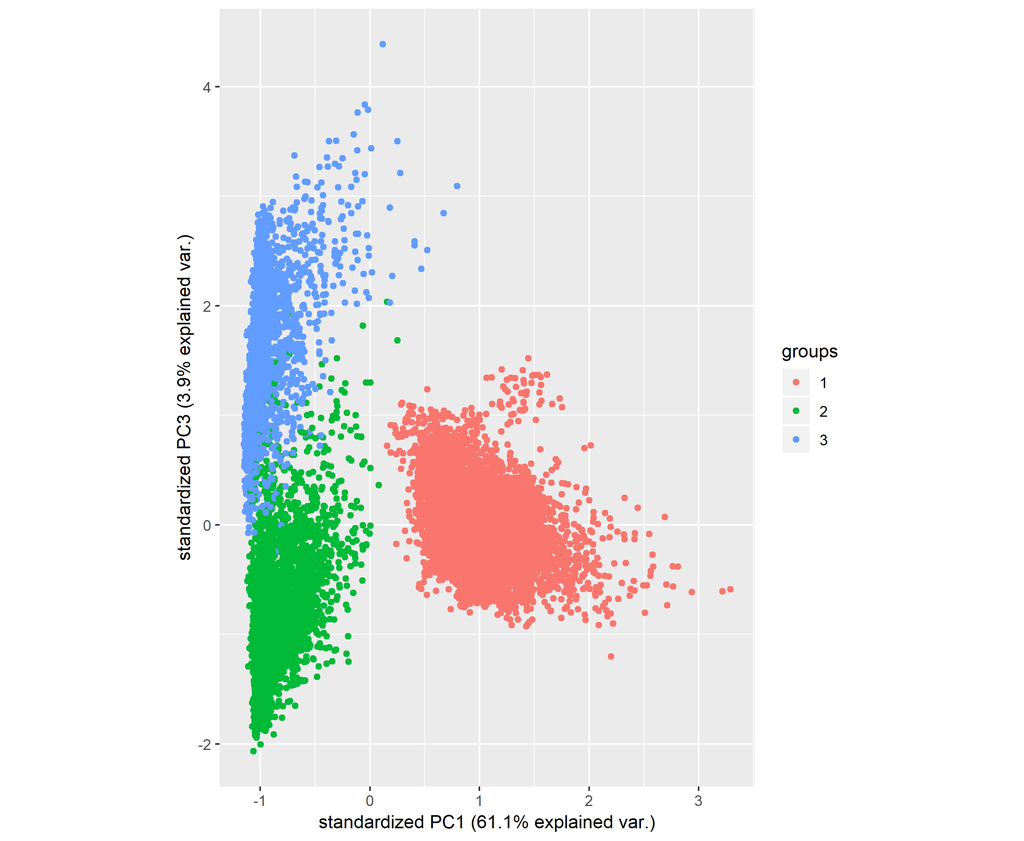

Trzy klastry w oryginalnych danych

Postanowiliśmy sprawdzić jak algorytm k-średnich podzieli zbiór uzyskany z PCA(`data_ade`) na 3 klastry.

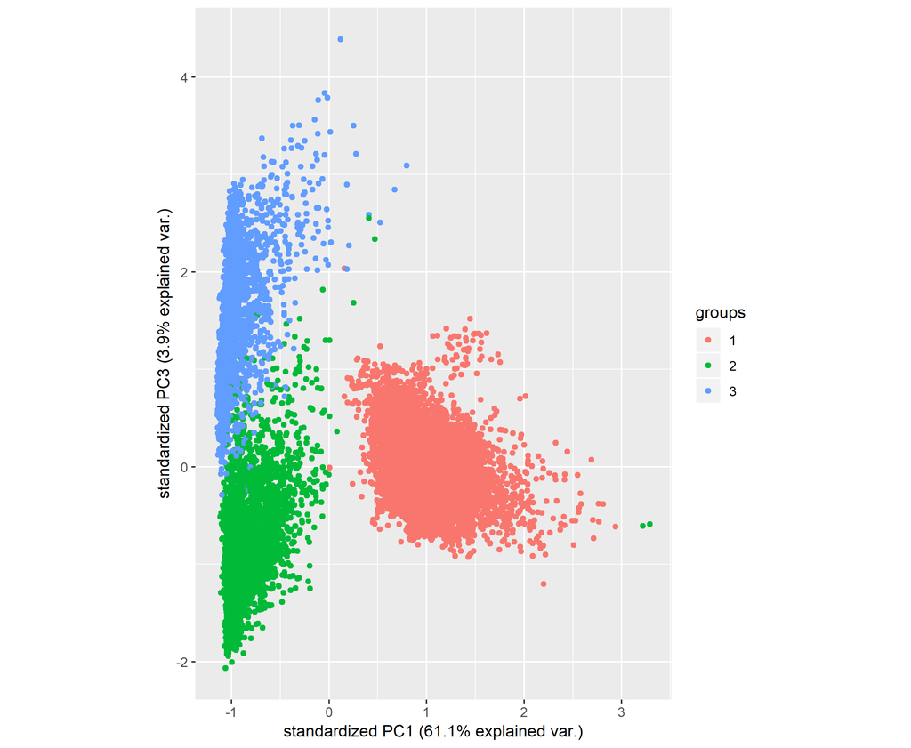

Trzy klastry uzyskane algorytmem k-średnich

Okazało się, że algorytm pomylił się tylko w 50 punktach na 10299 obserwacji.

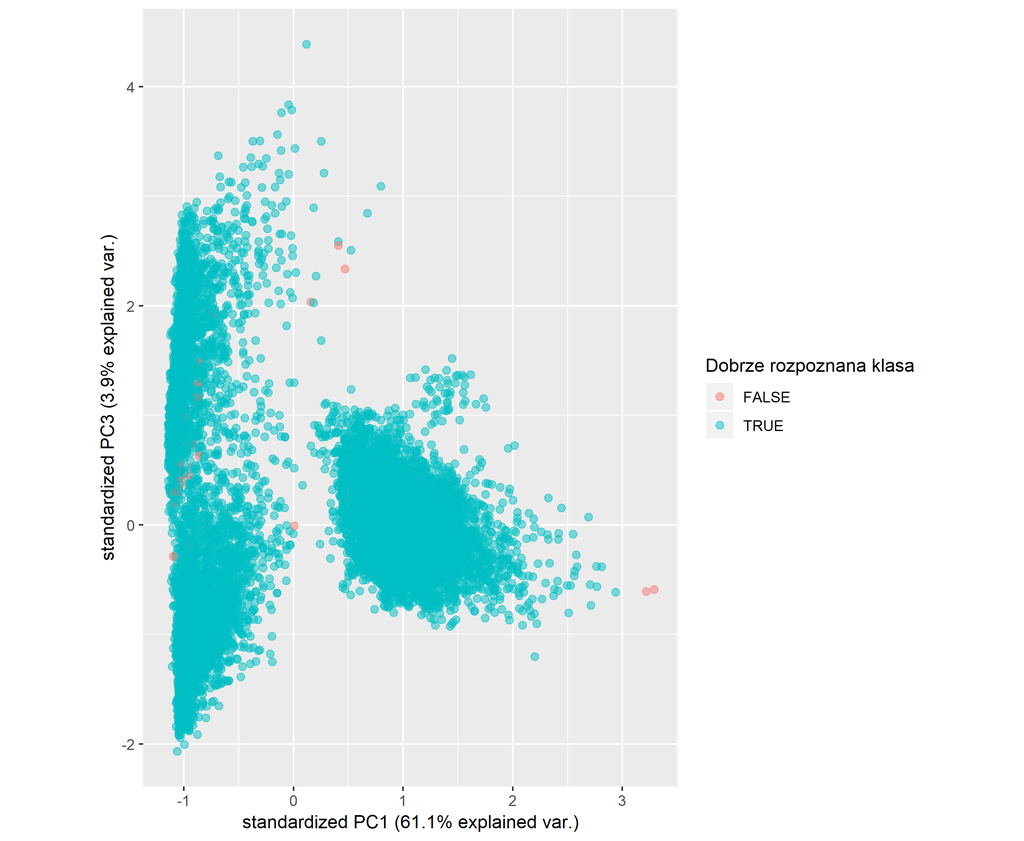

Zaznaczone punkty, które zostały przypisane do złego klastra